# Replication study: Association between the blood cadmium level and Alzheimer’s disease mortality risk in older US adults from NHANES data

## Survival analysis

### KM curve

The number of person months of follow-up from NHANES Mobile Examination Center (MEC) date is used as the survival time. Since the sample weights are calculated based on MEC weights, the MEC follow-up months seem more plausible.

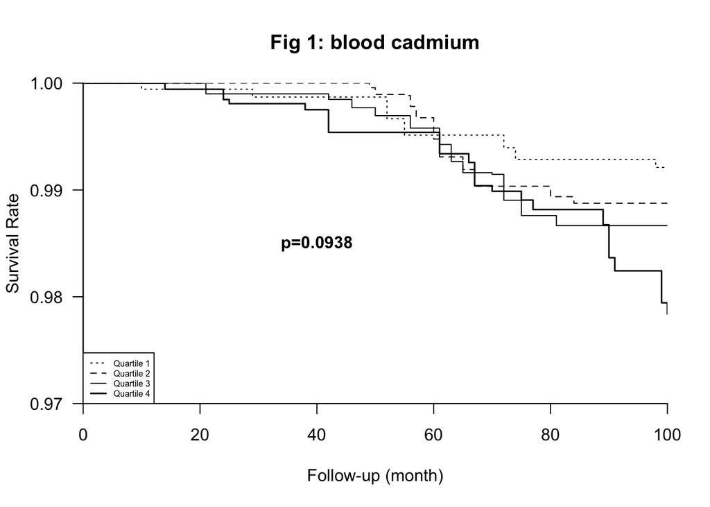

```r
# compute KM curves
s1 <- svykm(Surv(time, dead) ~ cadmium_qr, design = nhanes_svy)

# Logrank test is used to compare survival distributions
s1test <- svylogrank(Surv(time, dead) ~ cadmium_qr, design = nhanes_svy)

# make a KM plot
plot(s1[[1]], ylim = round(c(0.97, 1), 2), xlim = c(0, 100), bty = "l", lty = "dotted", ylab = "Survival Rate", xlab = "Follow-up (month)", las = 1, yaxt = "n", xaxs = "i", yaxs = "i", main = "Fig 1: blood cadmium")
axis(2, at = seq(0.97, 1, 0.01), las = 1)
lines(s1[[2]], ylim = round(c(0.97, 1), 2), xlim = c(0, 100), lty = "dashed")
lines(s1[[3]], ylim = round(c(0.97, 1), 2), xlim = c(0, 100), lty = "solid")
lines(s1[[4]], ylim = round(c(0.97, 1), 2), xlim = c(0, 100), lty = "solid", lwd = 1.5)
legend("bottomleft", paste("Quartile", 1:4), lty = c("dotted", "dashed", "solid", "solid"), lwd = c(rep(1, 3), 1.5), cex = 0.5)
text(40, 0.985, paste0("p=", round(s1test[[2]][2], 4)), font = 2)
```

### Cox model

```r
# crude HR
model0 <- svycoxph(Surv(time, dead) ~ cadmium_qr, nhanes_svy)

# adjusted HR
model1 <- svycoxph(Surv(time, dead) ~ cadmium_qr + age + I(age^2) + gender + ethnicity + education + income + cotinine, nhanes_svy)

# output
coxresult <- function(model) {
  summ <- summary(model)$conf.int[, c("exp(coef)", "lower .95", "upper .95")] %>%
  round(., 2) %>%
  as.data.frame()
  summ %<>%
    filter(grepl("cadmium_qr", rownames(summ))) %>%
  mutate(HR = paste(`exp(coef)`, " (", `lower .95`, "-", `upper .95`, ")")) %>%
  dplyr::select(HR) %>%
  rbind("1.00 (ref)", .)
  rownames(summ) <- c(paste0("Quartile ", 1:4, " (", c("<=0.3", "0.3-0.4", "0.4-0.6", ">0.6"), ")"))
  summ
}

hr <- cbind(coxresult(model0), coxresult(model1))
```

```
## Stratified 1 - level Cluster Sampling design (with replacement)
## With (87) clusters.
## subset(nhanes_svy_all, inAnalysis)
## Stratified 1 - level Cluster Sampling design (with replacement)
## With (87) clusters.
## subset(nhanes_svy_all, inAnalysis)
```

```r
colnames(hr) <- c("Crude HR (95 % CIs)", "Adjusted HR (95 % CIs)")

# trend test is carried out by the ninth method in the second reference paper
# the median of the last interval is chosen as (0.6+1)/2
coxtrend <- function(model) {
  summ <- summary(model)$coef
  hr <- summ[grepl("cadmium_qr", rownames(summ)), "exp(coef)"]

  trenddata <- mergedata %>%
  filter(inAnalysis == 1 & cadmium_qr != "Quartile1") %>%
  mutate(n = case_when(cadmium_qr == "Quartile2" ~ sum(cadmium_qr == "Quartile2"), cadmium_qr == "Quartile3" ~ sum(cadmium_qr == "Quartile3"), cadmium_qr == "Quartile4" ~ sum(cadmium_qr == "Quartile4")), hr = case_when(cadmium_qr == "Quartile2" ~ hr[1], cadmium_qr == "Quartile3" ~ hr[2], cadmium_qr == "Quartile4" ~ hr[3]), cadmium_median = case_when(cadmium_qr == "Quartile2" ~ (0.3+0.4)/2, cadmium_qr == "Quartile3" ~ (0.4+0.6)/2, cadmium_qr == "Quartile4" ~ (0.6+1)/2))

  lm1 <- lm(hr ~ cadmium_median, data = trenddata, weights = trenddata$n)
  pval <- summary(lm1)$coef[2, "Pr(>|t|)"] %>% round(., 3)
  pval
}

coxtrend(model0)
```

```
## Stratified 1 - level Cluster Sampling design (with replacement)
## With (87) clusters.
## subset(nhanes_svy_all, inAnalysis)
```

```
## [1] 0
```

```r
coxtrend(model1)
```

```
## Stratified 1 - level Cluster Sampling design (with replacement)
## With (87) clusters.
## subset(nhanes_svy_all, inAnalysis)
```

```
## [1] 0
```

```r
(hr %<>%
  rbind(., pval = c(coxtrend(model0), coxtrend(model1))))
```

```
## Stratified 1 - level Cluster Sampling design (with replacement)
## With (87) clusters.
## subset(nhanes_svy_all, inAnalysis)
## Stratified 1 - level Cluster Sampling design (with replacement)
## With (87) clusters.
## subset(nhanes_svy_all, inAnalysis)
```

|  | Crude HR (95 % CIs) | Adjusted HR (95 % CIs) |
| --- | --- | --- |
| Quartile 1 (<=0.3) | 1.00 (ref) | 1.00 (ref) |
| Quartile 2 (0.3-0.4) | 1.63 ( 0.78 - 3.39 ) | 1.45 ( 0.75 - 2.8 ) |
| Quartile 3 (0.4-0.6) | 1.8 ( 1.1 - 2.95 ) | 1.3 ( 0.82 - 2.06 ) |
| Quartile 4 (>0.6) | 1.61 ( 0.89 - 2.9 ) | 1.47 ( 0.82 - 2.62 ) |
| pval | 0 | 0 |

```r
# xtable(hr)
```

## Reference

Min, J., Min, K. (2016) Blood cadmium levels and Alzheimer’s disease mortality risk in older US adults. Environmental Health. DOI 10.1186/s12940-016-0155-7

Brownstein, N.C., Cai, J. Tests of trend between disease outcomes and ordinal covariates discretized from underlying continuous variables: simulation studies and applications to NHANES 2007–2008. BMC Med Res Methodol 19, 2 (2019). https://doi.org/10.1186/s12874-018-0630-7